# s670-HW5

Ruchik Rohit Dama

10/29/2021

#### DISCUSSED WITH SHASHANK KUMAR.

#### READING THE FILES:-

```r
#data = read.delim("", header=F, sep=" ")
data = read.delim(file = "../ASSIGNMENT 5/curry2015-16.txt", header = TRUE, sep = "", dec = ".")
data = data[,c('EVENT_TYPE','SHOT_MADE_FLAG','SHOT_DISTANCE','LOC_X','LOC_Y','SHOT_TYPE')]
```

### QUESTION 1:-Plot the data to show the location of Curry’s shots using color to distinguish between made and missed shots, similarly to the picture below but more colorblind-friendly. (You don’t have to include the picture of the court unless you want to show off.) NB: It should use coord fixed() since the units are the same for both axes.

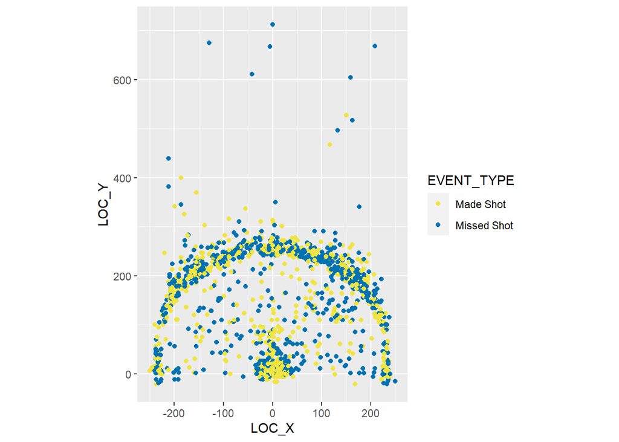

```r
ggplot(data, aes(x = LOC_X, y = LOC_Y, color = EVENT_TYPE))  +
  geom_point() +
  coord_fixed(ratio = 1) +
  scale_color_manual(values = cb_palette, labels = c("Made Shot", "Missed Shot"))
```

#### Using ggplot to show the location of Curry’s shots and using a different color palette to be more colorblinf-friendly.

### Question 2:- Fit a logistic regression to predict whether the shot is made, using the single predictor SHOT DISTANCE. Draw an appropriate ggplot of the fitted curve and write an equation for the fit.

```r
data.logit = glm(SHOT_MADE_FLAG ~ SHOT_DISTANCE,
family = binomial, data = data)
summary(data.logit)
```

```
##
## Call:
## glm(formula = SHOT_MADE_FLAG ~ SHOT_DISTANCE, family = binomial,
##     data = data)
##
## Deviance Residuals:
##     Min       1Q   Median       3Q      Max
## -1.4159  -1.0996   0.9563   1.2309   1.6654
##
## Coefficients:
##               Estimate Std. Error z value Pr(>|z|)
## (Intercept)    0.54508    0.09606   5.674 1.39e-08 ***
## SHOT_DISTANCE -0.03045    0.00467  -6.521 6.97e-11 ***
## ---
## Signif. codes:  0 '***' 0.001 '**' 0.01 '*' 0.05 '.' 0.1 ' ' 1
##
## (Dispersion parameter for binomial family taken to be 1)
##
##     Null deviance: 2215.2  on 1597  degrees of freedom
## Residual deviance: 2171.0  on 1596  degrees of freedom
## AIC: 2175
##
## Number of Fisher Scoring iterations: 4
```

#### Using glm and only one predictor (SHOT_DISTANCE) to fit a logistic regression and to predict whether the shot is made or not. After fitting the data explicitly, We use summary for getting the equation. Summary gives us a lot of information and noe using the information from coefficients:-

#### Using the Estimate column to get the Equation:-

#### logit[p(SHOT_MADE)]=(Estimate_Intercept) + (Estimate_coefficient)*(SHOT_DISTANCE)

#### logit[p(SHOT_MADE)]=0.545 + (-0.030)*(SHOT_DISTANCE)

#### Plotting an appropriate ggplot of the logistic regression

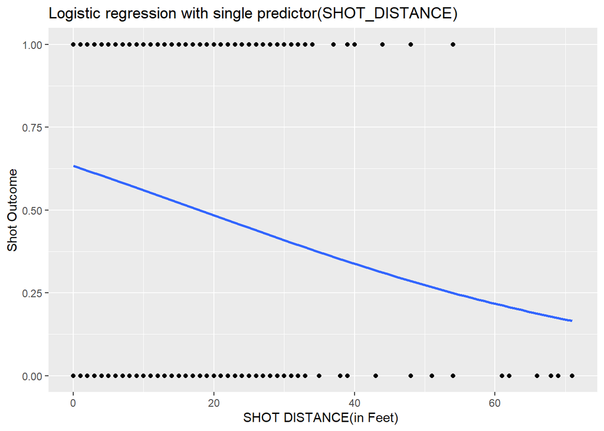

```r
ggplot(data,aes(x=SHOT_DISTANCE,y=SHOT_MADE_FLAG))+geom_point(height = 0.1,width=0.20)+
geom_smooth(method='glm',method.args=(list(family='binomial')),se=FALSE)+
xlab('SHOT DISTANCE(in Feet) ')+ylab('Shot Outcome')+labs(title='Logistic regression with single predictor(SHOT_DISTANCE)')
```

### Question 3:- Plot the residuals in a way that shows where the logistic regression doesn’t fit the data well.Describe in some detail how the model is inaccurate.

#### Plotting the Residual Plots, between the residual values and SHOT_DISTANCE.

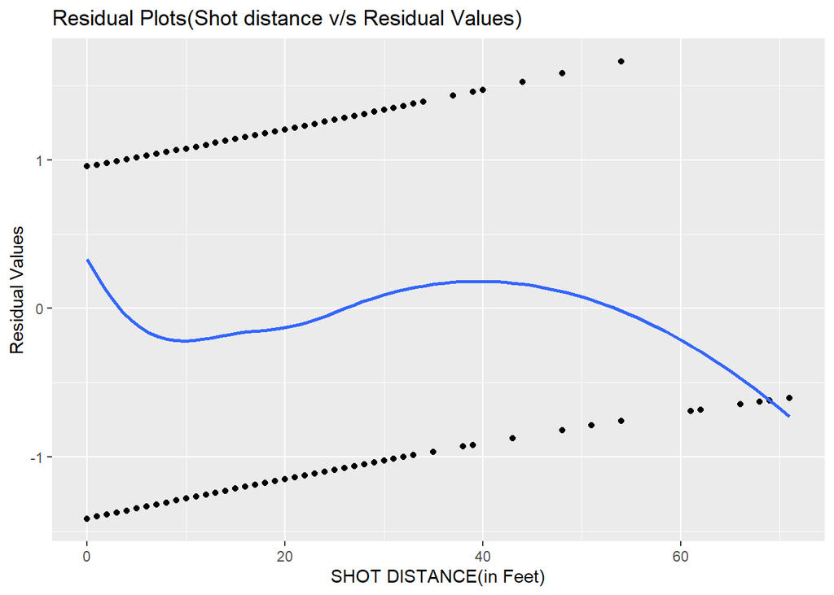

```r
data.logit.df = data.frame(data,
                   .fitted = fitted.values(data.logit),
                   .resid = residuals(data.logit))
ggplot(data.logit.df,aes(x =SHOT_DISTANCE , y = .resid))+geom_point(height = 0.1, width = 0.2)+geom_smooth(method='loess',se=FALSE)+labs(title = "Residual Plots(Shot distance v/s Residual Values)",x="SHOT DISTANCE(in Feet)",y="Residual Values")
```

### Describe in some detail how the model is inaccurate.

#### From the above residual plot, we can see that the plot is having a curves, But for a model to be accurate the residual plots should not curves but it should be a straight line near the zero line.So, to reduce the dip in the curve and bring the graph near zero line and for a better model, let’s add a new variable that gives the type of the shot i.e is it a 2 pointer or a 3 pointer.

### QUESTION 4:-Fit a better model. You could try a different functional form or a model with more predictors (as long as you use the predictors sensibly.) Your model doesn’t have to be perfect, just better. Draw a graph that shows how your model differs from the simple logistic regression, and convince us that your model is better.

```r
 data <- data %>%
    mutate(SHOT_TYPE = recode(SHOT_TYPE,
                      "2PT Field Goal" = "0",
                      "3PT Field Goal" = "1"))
```

#### Fitting the new model. Using log(SHOT_DISTANCE +0.1) to handle log(0) values.

```r
data.logit2 = glm(SHOT_MADE_FLAG ~ log(SHOT_DISTANCE+0.1)+SHOT_TYPE,
family = binomial, data = data)
summary(data.logit2)
```

```
##
## Call:
## glm(formula = SHOT_MADE_FLAG ~ log(SHOT_DISTANCE + 0.1) + SHOT_TYPE,
##     family = binomial, data = data)
##
## Deviance Residuals:
##     Min       1Q   Median       3Q      Max
## -1.8471  -1.1034   0.6331   1.2471   1.3726
##
## Coefficients:
##                          Estimate Std. Error z value Pr(>|z|)
## (Intercept)               0.69180    0.10642   6.501 8.00e-11 ***
## log(SHOT_DISTANCE + 0.1) -0.35334    0.05649  -6.255 3.98e-10 ***
## SHOT_TYPE1                0.27026    0.15146   1.784   0.0744 .
## ---
## Signif. codes:  0 '***' 0.001 '**' 0.01 '*' 0.05 '.' 0.1 ' ' 1
##
## (Dispersion parameter for binomial family taken to be 1)
##
##     Null deviance: 2215.2  on 1597  degrees of freedom
## Residual deviance: 2151.9  on 1595  degrees of freedom
## AIC: 2157.9
##
## Number of Fisher Scoring iterations: 4
```

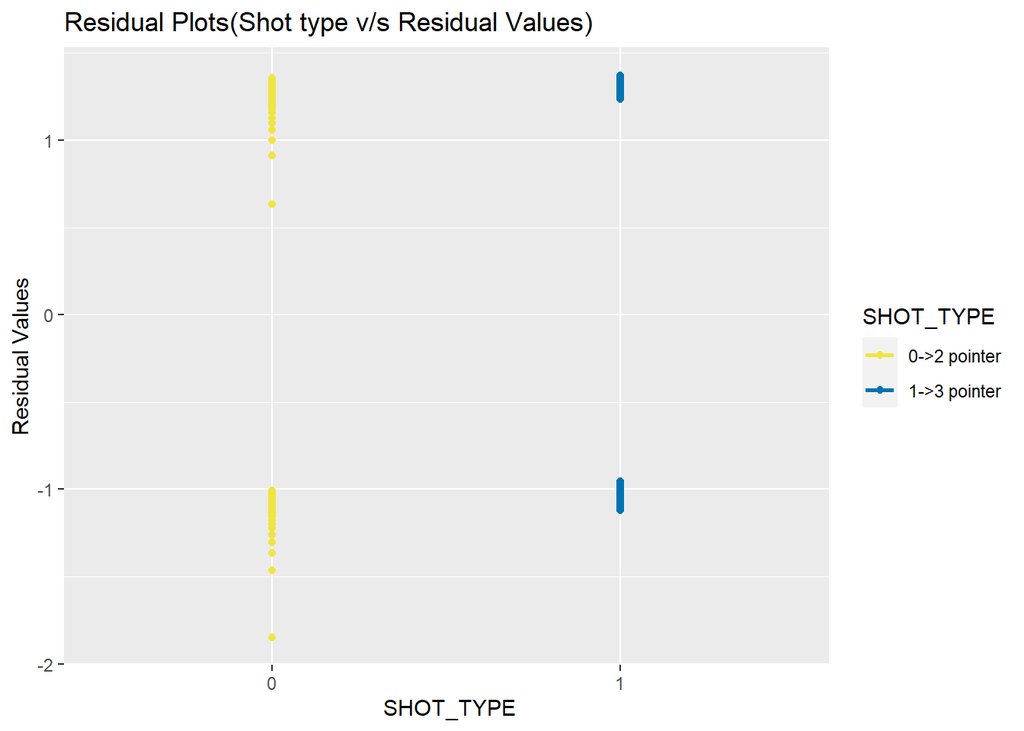

```r
data.logit.df2 = data.frame(data,
                   .fitted = fitted.values(data.logit2),
                   .resid = residuals(data.logit2))
ggplot(data.logit.df2,aes(x =SHOT_TYPE , y = .resid,color=SHOT_TYPE))+geom_point(height = 0.1, width = 0.2)+geom_smooth(method='loess',se=FALSE)+labs(title = "Residual Plots(Shot type v/s Residual Values)",x=" SHOT_TYPE",y="Residual Values")+
scale_color_manual(values = cb_palette, labels = c("0->2 pointer", "1->3 pointer"))
```

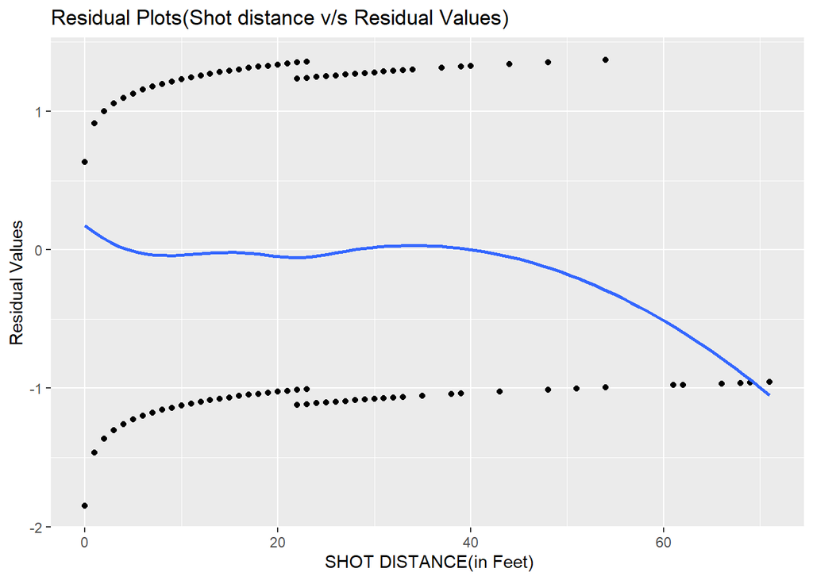

```r
data.logit.df2 = data.frame(data,
                   .fitted = fitted.values(data.logit2),
                   .resid = residuals(data.logit2))
ggplot(data.logit.df2,aes(x =SHOT_DISTANCE , y = .resid))+geom_point(height = 0.1, width = 0.2)+geom_smooth(method='loess',se=FALSE)+labs(title = "Residual Plots(Shot distance v/s Residual Values)",x=" SHOT DISTANCE(in Feet)",y="Residual Values")
```